[output not shown]

### Cel Projektu

Celem projektu jest zbudowanie modelu VAR, mając na celu analizę przyczynowości Grangera i uzyskanie informacji potencjalnego wzajemnego wpływu rynków.

## Przygotowanie danych

### Biblioteki

```r
library(dplyr)
library(lubridate)
library(zoo)
library(tseries)
library(vars)
```

```r
library(ggplot2)
library(vars)
```

### Wczytanie danych

```r
# Wczytanie danych
Oil <- read.csv("Brent-Oil.csv", sep = ",", header = TRUE)
Wig <- read.csv("wig.csv", sep = ",", header = TRUE)
Dax <- read.csv("dax.csv", sep = ",", header = TRUE)
Bel <- read.csv("bel.csv", sep = ",", header = TRUE)
EurUsd <- read.csv("eurusd.csv", sep = ",", header = TRUE)
PlnUsd <- read.csv("plnusd.csv", sep = ",", header = TRUE)
```

### Wybór odpowiednich kolumn

```r
# Wybieranie odpowiednich kolumn
Oil <- Oil[, c(1:2)]
Wig <- Wig[, c(1,5)]
Dax <- Dax[, c(1,5)]
Bel <- Bel[, c(1,5)]
EurUsd <- EurUsd[, c(1,5)]
PlnUsd <- PlnUsd[, c(1,5)]
```

### Zmiana nazw kolumn

```r
names(Oil) <- c("Date", "Oil")
names(Wig) <- c("Date", "Wig")
names(Dax) <- c("Date", "Dax")
names(Bel) <- c("Date", "Bel")
names(EurUsd) <- c("Date", "EurUsd")
names(PlnUsd) <- c("Date", "PlnUsd")
```

### Utworzenie ramki danych

```r
library(lubridate)
#Tworzenie ramki danych
Data <- data.frame(seq(as.Date("2010-01-01"), to = as.Date("2022-11-29"), by = "day"))
names(Data) = c("Date")
Data$Dzien <- wday(Data$Date, week_start=1)
Data <- Data[!(Data$Dzien ==6 | Data$Dzien == 7), 1]
Data <- data.frame(Data)
names(Data) <- c("Date")

# Wczytywanie danych
Oil$Date <- mdy(Oil$Date)
Wig$Date <- ymd(Wig$Date)
Bel$Date <- ymd(Bel$Date)
Dax$Date <- ymd(Dax$Date)
EurUsd$Date <- ymd(EurUsd$Date)
PlnUsd$Date <- ymd(PlnUsd$Date)
library(dplyr)
# Łaczenie wszytskich ramek danych w jedna
df <- Data |> left_join(Wig, by="Date")
df <- df %>% left_join(Bel, by="Date")
df <- df %>% left_join(Dax, by="Date")
df <- df %>% left_join(Oil, by="Date")
df <- df %>% left_join(EurUsd, by="Date")
df <- df %>% left_join(PlnUsd, by="Date")

rr = list()

for (i in 1:nrow(df)){
  if(sum(is.na(df[i,])) >= 4){
    rr <- append(rr, i)
  }
}
rr <- unlist(rr)
df <- df[-rr,]
data <- df[, 1:5]
head(data)
```

```
##         Date     Wig     Bel     Dax   Oil
## 2 2010-01-04 2444.58 2563.97 6048.30 80.12
## 3 2010-01-05 2462.30 2587.77 6031.86 80.59
## 4 2010-01-06 2472.83 2596.43 6034.33 81.89
## 5 2010-01-07 2436.40 2590.68 6019.36 81.51
## 6 2010-01-08 2440.42 2591.64 6037.61 81.37
## 7 2010-01-11 2473.50 2585.86 6040.50 80.97
```

**Uwaga:** Wszelkie obliczenia są realizowane z wykorzystaniem programu R, a przyjęty poziom istotności wynosi α = 5%.

### Uzupełnienie braków danych

Metoda interpolacji liniowej - funkcja na.approx()

```r
for (i in 2:ncol(df))
{
  df[,i] <- na.approx(df[,i], na.rm = FALSE)
}
```

### Przewalutowanie do $

```r
df <- df %>% dplyr::mutate(Wig = Wig * PlnUsd, Dax = Dax * EurUsd, Bel = Bel * EurUsd)
df <- df %>% dplyr::select("Date", "Wig", "Dax", "Bel", "Oil")
```

Fragment gotowego zbioru danych:

|  | Date | Wig | Dax | Bel | Oil |
| --- | --- | --- | --- | --- | --- |
| 2 | 2010-01-04 | 858.8054 | 8716.810 | 3695.194 | 80.12 |
| 3 | 2010-01-05 | 871.1864 | 8662.354 | 3716.296 | 80.59 |
| 4 | 2010-01-06 | 867.8644 | 8688.832 | 3738.600 | 81.89 |
| 5 | 2010-01-07 | 850.9614 | 8610.093 | 3705.709 | 81.51 |
| 6 | 2010-01-08 | 850.8280 | 8692.951 | 3731.443 | 81.37 |
| 7 | 2010-01-11 | 883.9300 | 8765.974 | 3752.600 | 80.97 |

### Indeksy dzienne

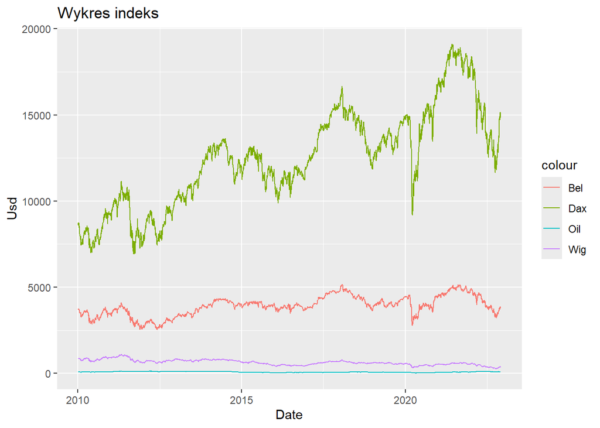

## Logarytmiczne stopy zwrotu

W kolejnym kroku dane zostały przekształcone według wzoru: $R_l = \ln(\frac{P_t}{p_{t-1}})$

gdzie:

- $R_l$ - logarytmiczna stopa zwrotu,
- $P_t$ - wartość zamknięcia indeksu w czasie t,
- $P_{t−1}$ - wartość zamknięcia indeksu w czasie t-1,

Otrzymujemy logarytmiczne stopy zwrotu

```r
stopy_zwrotu <- as.data.frame(matrix(0, nrow(df)-1, 5))

stopy_zwrotu[,1] = df$Date[-1]

for(i in 1:nrow(df)-1)
{
  stopy_zwrotu[i,2]=log(df[i+1,2] / df[i,2])
  stopy_zwrotu[i,3]=log(df[i+1,3] / df[i,3])
  stopy_zwrotu[i,4]=log(df[i+1,4] / df[i,4])
  stopy_zwrotu[i,5]=log(df[i+1,5] / df[i,5])
}
```

| Date | Wig | Dax | Bel | Oil |
| --- | --- | --- | --- | --- |
| 2010-01-05 | 0.0143136 | -0.0062668 | 0.0056947 | 0.0058491 |
| 2010-01-06 | -0.0038204 | 0.0030520 | 0.0059835 | 0.0160023 |
| 2010-01-07 | -0.0196687 | -0.0091034 | -0.0088366 | -0.0046512 |
| 2010-01-08 | -0.0001568 | 0.0095774 | 0.0069206 | -0.0017191 |
| 2010-01-11 | 0.0381678 | 0.0083651 | 0.0056538 | -0.0049279 |
| 2010-01-12 | -0.0166142 | -0.0177899 | -0.0095973 | -0.0208406 |

Wykres

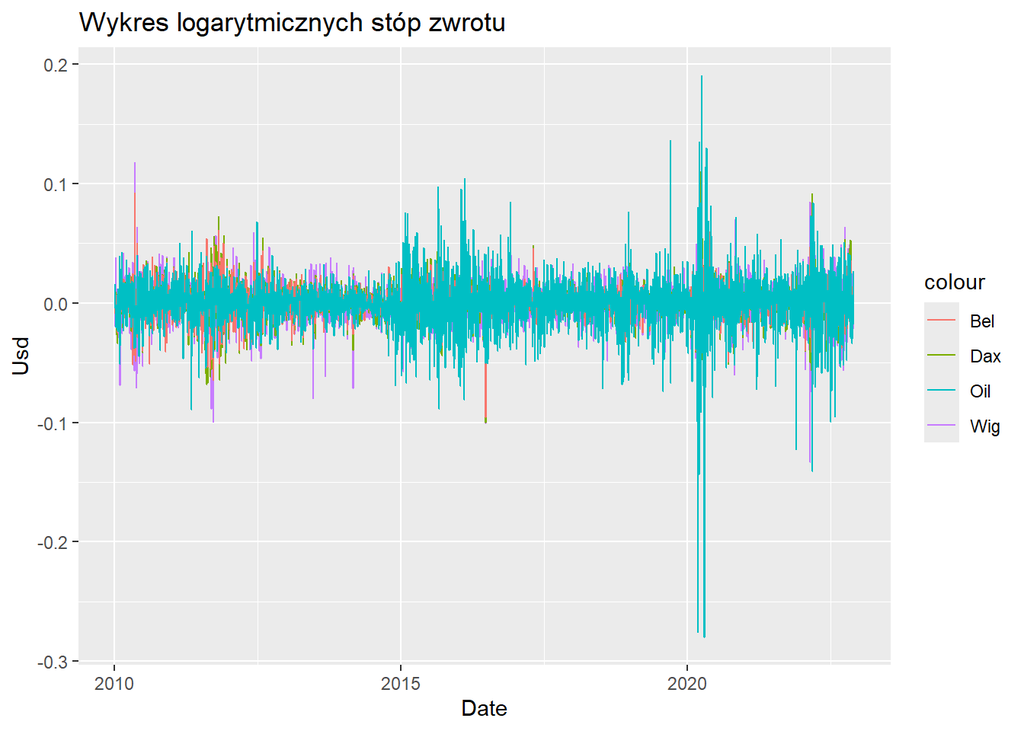

## Test stacjonarności

Dickey’a-Fuller adf.test()

*H0 : szereg jest niestacjonarny*  
*H1 : szereg jest stacjonarny.*

```r
adf_resut <- as.data.frame(matrix(0, 1, 4))

adf_resut[1,1] <- adf.test(stopy_zwrotu[,2],alternative = c("stationary"))$p.value
adf_resut[1,2] <- adf.test(stopy_zwrotu[,3],alternative = c("stationary"))$p.value
adf_resut[1,3] <- adf.test(stopy_zwrotu[,4],alternative = c("stationary"))$p.value
adf_resut[1,4] <- adf.test(stopy_zwrotu[,5],alternative = c("stationary"))$p.value
```

```r
names(adf_resut) <- c("Wig", "Dax", "Bel", "Oil")
stopy_zwrotu <- stopy_zwrotu[,-1]
adf_resut
```

```
##    Wig  Dax  Bel  Oil
## 1 0.01 0.01 0.01 0.01
```

Szeregi stóp zwrotu są stacjonarne, ponieważ żadna wartość nie przekracza 0,05

## Model VAR

### Rząd opóźnień

```r
var <- VARselect(stopy_zwrotu)$selection
```

[output not shown]

Kryteria HQ oraz SC wskazują na wybór modelu z 1 opóźnieniem, natomiast AIC i FPE z 8 opóźnieniami, jednakże wartości kryterium FPE są w przybliżeniu równe zero, a zatem ostatecznie analizując pierwsze 3 kryteria zostaje wybrany model VAR rzędu p=1.

### Model VAR z opóźnieniem rzędu p=1

```r
model <- VAR(stopy_zwrotu, p=1)
summary(model)
```

```
##
## VAR Estimation Results:
## =========================
## Endogenous variables: Wig, Dax, Bel, Oil
## Deterministic variables: const
## Sample size: 3327
## Log Likelihood: 39909.97
## Roots of the characteristic polynomial:
## 0.06241 0.06241 0.0382 0.007128
## Call:
## VAR(y = stopy_zwrotu, p = 1)
##
##
## Estimation results for equation Wig:
## ====================================
## Wig = Wig.l1 + Dax.l1 + Bel.l1 + Oil.l1 + const
##
##          Estimate Std. Error t value Pr(>|t|)
## Wig.l1 -0.0645211  0.0240881  -2.679  0.00743 **
## Dax.l1  0.1393177  0.0484575   2.875  0.00407 **
## Bel.l1  0.0523729  0.0519592   1.008  0.31355
## Oil.l1  0.0214868  0.0131777   1.631  0.10308
## const  -0.0002857  0.0002888  -0.989  0.32265
## ---
## Signif. codes:  0 '***' 0.001 '**' 0.01 '*' 0.05 '.' 0.1 ' ' 1
##
##
## Residual standard error: 0.01665 on 3322 degrees of freedom
## Multiple R-Squared: 0.01747, Adjusted R-squared: 0.01629
## F-statistic: 14.77 on 4 and 3322 DF,  p-value: 5.8e-12
##
##
## Estimation results for equation Dax:
## ====================================
## Dax = Wig.l1 + Dax.l1 + Bel.l1 + Oil.l1 + const
##
##          Estimate Std. Error t value Pr(>|t|)
## Wig.l1 -0.0167113  0.0207751  -0.804  0.42123
## Dax.l1  0.0397738  0.0417928   0.952  0.34132
## Bel.l1 -0.0186969  0.0448129  -0.417  0.67654
```

[output cut: 48 more lines]

```
##
##
## Covariance matrix of residuals:
##           Wig       Dax       Bel       Oil
## Wig 0.0002772 1.637e-04 1.510e-04 1.006e-04
## Dax 0.0001637 2.062e-04 1.737e-04 8.992e-05
## Bel 0.0001510 1.737e-04 1.786e-04 8.814e-05
## Oil 0.0001006 8.992e-05 8.814e-05 5.260e-04
##
## Correlation matrix of residuals:
##        Wig    Dax    Bel    Oil
## Wig 1.0000 0.6850 0.6785 0.2634
## Dax 0.6850 1.0000 0.9054 0.2731
## Bel 0.6785 0.9054 1.0000 0.2876
## Oil 0.2634 0.2731 0.2876 1.0000
```

Korelacje reszt modelu Korelacje dodatnie, szczególnie silne:

DAX i BEL (0.91) – podobne rynki, silna korelacja

WIG i DAX (0.69), WIG i BEL (0.68) – potwierdzają silne związki między rynkami

- na polską giełdę (WIG) w istotny sposób wpływają jedynie stopy zwrotu dla Polski z opóźnieniem 1 oraz stopy zwrotu niemieckiej giełdy(DAX),
- na niemiecką giełdę w istotny sposób wpływa jedynie cena ropy naftowej,
- na belgijską giełdę(Bel) w istotny sposób nie wpływa, żadna ze zmiennych,
- na cenę ropy naftowej(Oil) w istotny sposób wpływają stopy zwrotu giełd polskiej, niemieckiej oraz belgi- jskiej.

## Weryfikacja modelu

### Istotność zmiennych (t-studenta)

```r
coef_var <- as.data.frame(matrix(0, 5, 4))
names(coef_var) <- c("Wig", "Dax", "Bel", "Oil")

s <- summary(model)

coef_var[,1] <- s$varresult$Wig$coefficients[,4]
coef_var[,2] <- s$varresult$Dax$coefficients[,4]
coef_var[,3] <- s$varresult$Bel$coefficients[,4]
coef_var[,4] <- s$varresult$Oil$coefficients[,4]

coef_var
```

```
##           Wig         Dax        Bel          Oil
## 1 0.007430759 0.421229393 0.34523932 4.397332e-02
## 2 0.004065354 0.341323887 0.16064760 4.317634e-03
## 3 0.313546075 0.676543856 0.83515870 9.054093e-05
## 4 0.103082586 0.007489412 0.06468098 8.512291e-01
## 5 0.322651436 0.544892760 0.97125484 9.362019e-01
```

(Indeks poniżej 0,05 -> ma wpływ) Wig.l1 Istotny wpływ na Wig (p = 0.0074) – ujemny, jak wcześniej zauważyliśmy.

Dax.l1 Istotny wpływ na Wig (p = 0.0041) – pozytywny wpływ.

Istotny wpływ na Oil (p = 0.0043) – ujemny wpływ.

Brak istotności w pozostałych przypadkach.

Bel.l1 Silnie istotny wpływ na Oil (p < 0.001) – pozytywny.

W pozostałych przypadkach nieistotny.

4⃣Oil.l1 Istotny wpływ na Dax (p = 0.0075) – pozytywny.

Granicznie istotny wpływ na Bel (p = 0.0647)

Brak wpływu na siebie i Wig.

### Łączna istotność zmiennych (test F)

```r
F_test <- as.data.frame(matrix(0, 1, 4))
names(F_test) <- c("Wig", "Dax", "Bel", "Oil")

F_test[,1] <- pf(s$varresult$Wig$fstatistic[1], s$varresult$Wig$fstatistic[2], s$varresult$Wig$fstatistic[3], lower.tail = FALSE)
F_test[,2] <- pf(s$varresult$Dax$fstatistic[1], s$varresult$Dax$fstatistic[2], s$varresult$Dax$fstatistic[3], lower.tail = FALSE)
F_test[,3] <- pf(s$varresult$Bel$fstatistic[1], s$varresult$Bel$fstatistic[2], s$varresult$Bel$fstatistic[3], lower.tail = FALSE)
F_test[,4] <- pf(s$varresult$Oil$fstatistic[1], s$varresult$Oil$fstatistic[2], s$varresult$Oil$fstatistic[3], lower.tail = FALSE)

F_test
```

```
##           Wig        Dax        Bel        Oil
## 1 5.80044e-12 0.05026299 0.03159164 0.00176101
```

W modelu, w którym y to DAX, zmienne x nie miały istotnego wpływu. Pozostałe modele wykazują łączną istotność zmiennych (odrzucenie H₀.

### Autokorelacja (test Ljunga-Boxa)

*H0 :* $∀_j : ρ_j = 0$ − brak autokorelacji składnika losowego do rzędu p włącznie *H1 :* $∃_j : ρ_j ̸= 0$ − istnieje przynajmniej jedna autokorelacja różna od zera

```r
Box_test <- as.data.frame(matrix(0, 1, 4))
names(Box_test) <- c("Wig", "Dax", "Bel", "Oil")

Box_test[,1] <- Box.test(model$varresult$Wig$residuals, lag = 1, type = "Ljung-Box")$p.value
Box_test[,2] <- Box.test(model$varresult$Dax$residuals, lag = 1, type = "Ljung-Box")$p.value
Box_test[,3] <- Box.test(model$varresult$Bel$residuals, lag = 1, type = "Ljung-Box")$p.value
Box_test[,4] <- Box.test(model$varresult$Oil$residuals, lag = 1, type = "Ljung-Box")$p.value

Box_test
```

```
##         Wig       Dax       Bel       Oil
## 1 0.8466266 0.9847139 0.9367811 0.9844082
```

Brak podstaw do odrzucenia H0, brak autokorelacji w modelach.

### Normalność reszt ( Shapiro-Wilk)

*H0 : rozkład reszt jest normalny*  
*H1 : brak rozkładu normalnego reszt*

```r
norm_test <- as.data.frame(matrix(0, 1, 4))
names(norm_test) <- c("Wig", "Dax", "Bel", "Oil")

norm_test[,1] <- shapiro.test(model$varresult$Wig$residuals)$p.value
norm_test[,2] <- shapiro.test(model$varresult$Dax$residuals)$p.value
norm_test[,3] <- shapiro.test(model$varresult$Bel$residuals)$p.value
norm_test[,4] <- shapiro.test(model$varresult$Oil$residuals)$p.value

norm_test
```

```
##            Wig          Dax          Bel          Oil
## 1 1.496681e-33 3.486058e-35 5.737587e-37 1.015832e-43
```

Wartość p-value mniejsza od 5% pozwala na odrzucenie hipotezy zerowej, jednakże powołując się na Centralne Twierdzenie Graniczne został przyjęty asymptotyczny rozkład normalny.

## Przyczynowość w sensie Grangera

*H0 : zmienna X nie jest przyczyną w sensie Grangera zmiennej Y*  
*H1 : zmienna X jest przyczyną w sensie Grangera zmiennej Y*

```r
grang_test <- as.data.frame(matrix(0, 1, 4))
names(grang_test) <- c("Wig", "Dax", "Bel", "Oil")

shapiro.test(model$varresult$Wig$residuals)$p.value
```

```
## [1] 1.496681e-33
```

```r
grang_test[,1] <- causality(model, cause = c("Wig"))$Granger$p.value
grang_test[,2] <- causality(model, cause = c("Dax"))$Granger$p.value
grang_test[,3] <- causality(model, cause = c("Bel"))$Granger$p.value
grang_test[,4] <- causality(model, cause = c("Oil"))$Granger$p.value

grang_test
```

```
##         Wig          Dax         Bel        Oil
## 1 0.2371032 5.633775e-05 0.000215426 0.02941552
```

Jedynie dla WIG można stwierdzić, że nie zachodzi przyczynowość Grangera(wartość powyżej 0,05)

- giełda niemiecka9Dax) jest przyczyną w sensie Grangera względem pozostałych giełd i ceny ropy,
- giełda belgijska(Bel) jest przyczyną w sensie Grangera względem pozostałych giełd i ceny ropy,
- cena ropy naftowej(Oil) jest przyczyną w sensie Grangera względem pozostałych giełd.

#test reakcji na impuls

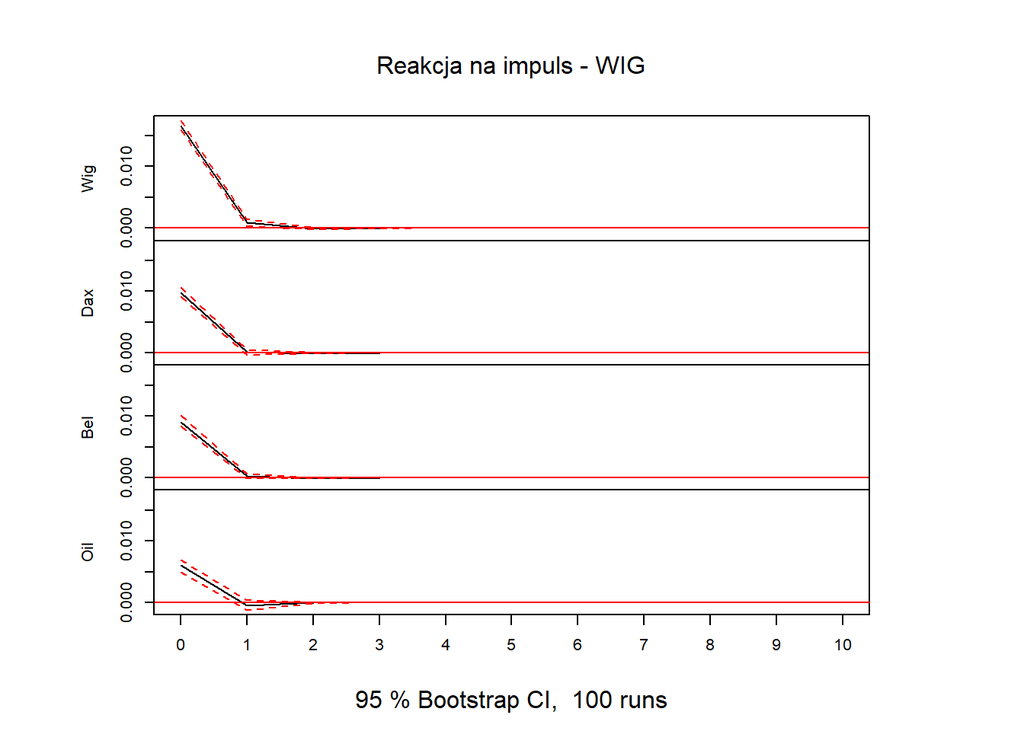

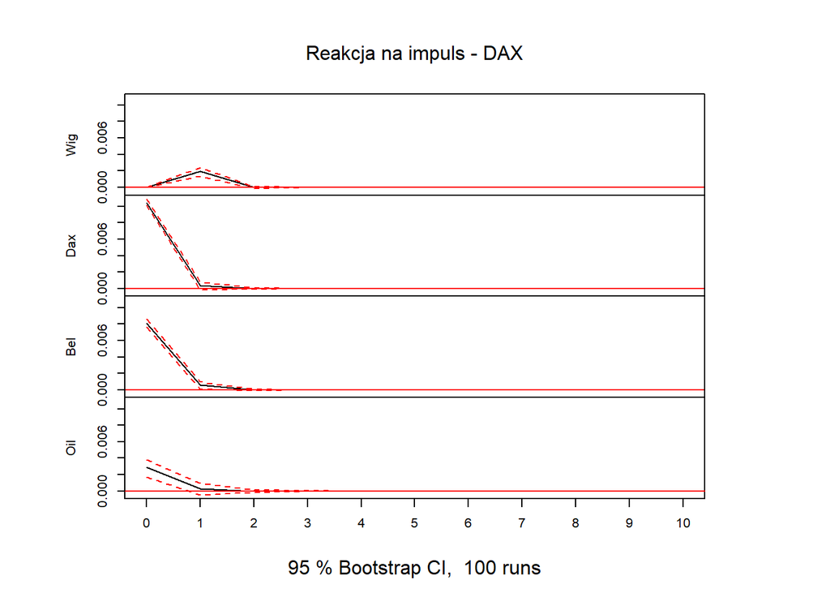

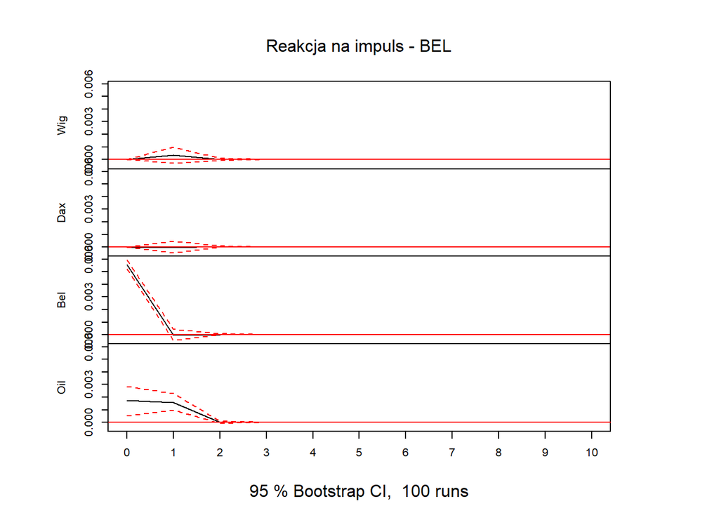

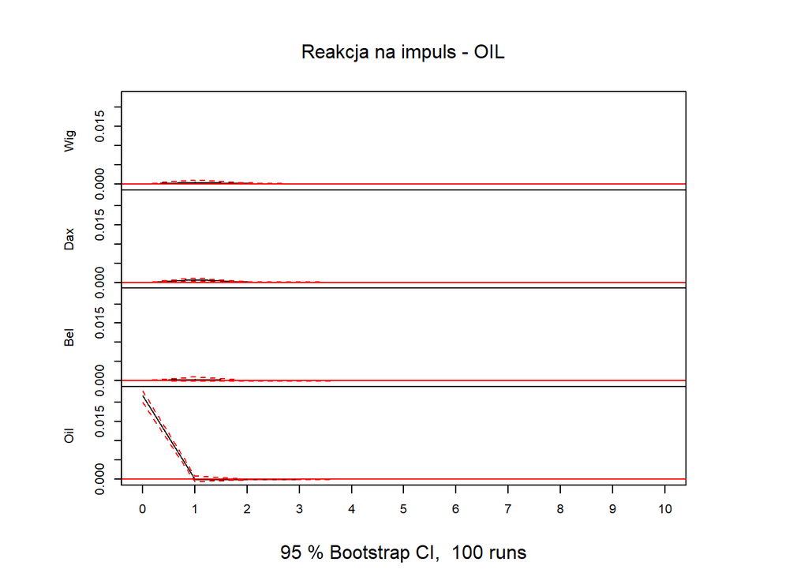

```r
plot_irf <- function(model, impulse, response_vars) {
  irf_result <- irf(model,
                    impulse = impulse,
                    response = response_vars,
                    n.ahead = 10,
                    ortho = TRUE,
                    runs = 100)
  plot(irf_result, main = paste("Reakcja na impuls -", toupper(impulse)))
}

# Lista zmiennych (impulsy i reakcje)
zmienne <- c("Wig", "Dax", "Bel", "Oil")

# Pętla: dla każdego impulsu rysuj reakcję pozostałych zmiennych
for (impuls in zmienne) {
  plot_irf(model, impulse = impuls, response_vars = zmienne)
}
```